# Zadanie1_Bagin.R

samuelbagin

2026-09-29

```r
library(palmerpenguins)
```

```r
if (interactive()) utils::View(penguins)

# funkcia na zobrazovanie grafov podla skupin
grafy_podla_skupin <- function(data = NULL, stlpec = NULL, podla = NULL,
              skupiny = NULL, nazov_hodnoty = NULL, nazov_skupiny = NULL) {

  if (is.null(skupiny)) {
    if (is.null(stlpec) || length(stlpec) != 1L ||
        !(stlpec %in% names(data))) {
      stop("Zadaj existujúci stĺpec. Dostupné: ",
           paste(names(data), collapse = ", "))
    }

    if (!is.numeric(data[[stlpec]])) {
      stop("Stĺpec ", stlpec, " musí obsahovať čísla.")
    }

    if (is.null(podla)) {
      skupiny <- list("Všetky merania" = data[[stlpec]])
    } else {
      if (length(podla) != 1L || !is.character(podla)) {
        stop("Podla musí byť názov jedného alebo dvoch stĺpcov.")
      }

      stlpce_podla <- trimws(strsplit(podla, "+", fixed = TRUE)[[1]])

      if (length(stlpce_podla) < 1L || length(stlpce_podla) > 2L ||
          any(!nzchar(stlpce_podla)) ||
          !all(stlpce_podla %in% names(data))) {
        stop("Podla musí obsahovať jeden alebo dva existujúce stĺpce.")
      }

      skupina <- if (length(stlpce_podla) == 1L) {
        data[[stlpce_podla]]
      } else {
        interaction(data[[stlpce_podla[1L]]],
                    data[[stlpce_podla[2L]]],
                    drop = TRUE, sep = " + ")
      }

      skupiny <- split(data[[stlpec]], skupina, drop = TRUE)
    }
  }


  if (is.null(nazov_hodnoty)) {
    nazov_hodnoty <- if (is.null(stlpec)) "Hodnota" else stlpec
  }

  if (is.null(nazov_skupiny)) {
    nazov_skupiny <- if (is.null(podla)) "Skupina" else podla
  }

  if (length(skupiny) == 0 || any(!vapply(skupiny, is.numeric, logical(1))) || any(lengths(skupiny) < 2)) {
    stop("Skupiny musia obsahovat aspon dve ciselne merania.")
  }

  if (is.null(names(skupiny))) {
    names(skupiny) <- paste("Skupina", seq_along(skupiny))
  }

  # veridis color scheme
  farby <- grDevices::colorRampPalette(
    c("#440154", "#21918C", "#FDE725")
  )(length(skupiny))

  rozsah <- range(unlist(skupiny))
  krivky <- lapply(skupiny, density)
  horna <- max(vapply(krivky, function(k) max(k$y), numeric(1)))

  povodne_nastavenia <- par(no.readonly = TRUE)
  on.exit(par(povodne_nastavenia))
  par(
    mfrow = c(ceiling((length(skupiny) + 3) / 3), 3),
    mar = c(3.8, 3.8, 2.6, 0.8),
    mgp = c(2.2, 0.7, 0),
    cex.main = 0.85
  )

  # histogram kazdej skupiny
  for (i in seq_along(skupiny)) {
    hist(skupiny[[i]], probability = TRUE,
         xlim = rozsah, border = "white",
         main = paste(nazov_skupiny, ":", names(skupiny)[i]),
         xlab = nazov_hodnoty, ylab = "hustota")
  }

  # krivky hustoty
  plot(NA, xlim = rozsah, ylim = c(0, horna),
       xlab = nazov_hodnoty, ylab = "hustota",
       main = paste("hustota podla", nazov_skupiny))

  for (i in seq_along(krivky)) {
    lines(krivky[[i]], col = farby[i], lwd = 2)
  }

  legend("topright", legend = names(skupiny),
         col = farby, lwd = 2, bty = "n", cex = 0.65)

  # stlpcovy graf priemerov
  priemery <- vapply(skupiny, mean, numeric(1))
  barplot(priemery, col = farby, xlab = nazov_skupiny,
          ylab = paste("priemer:", nazov_hodnoty), main = paste("priemer podla", nazov_skupiny))

  # boxplot
  boxplot(skupiny, horizontal = TRUE, col = farby,
          xlab = nazov_hodnoty, ylab = nazov_skupiny, main = paste("Boxplot podľa", nazov_skupiny))
}

# funkcia na vypocet zakladnych vlastnosti podla stlpca a filtra
popisne_statistiky <- function(data = NULL, stlpec = NULL,
                               podla = NULL, skupiny = NULL) {
  vypocitaj <- function(x) {
    list(
      count = length(x),
      mean = mean(x),
      median = median(x),
      modus = modeest::mfv(x),
      kvantily = quantile(x),
      rozsah = setNames(range(x), c("minimum", "maximum")),
      IQR = IQR(x),
      rozptyl = var(x),
      smerodajna_odchylka = sd(x)
    )
  }

  if (is.null(data) || is.null(stlpec) ||
      length(stlpec) != 1L || !(stlpec %in% names(data))) {
    stop("Stĺpec neexistuje. Dostupné stĺpce: ",
         paste(names(data), collapse = ", "))
  }

  if (!is.numeric(data[[stlpec]])) {
    stop("Stĺpec ", stlpec, " musí obsahovať čísla.")
  }

  if (is.null(podla)) {
    return(vypocitaj(data[[stlpec]]))
  }

  if (!is.character(podla) || length(podla) != 1L || is.na(podla)) {
    stop("Podla musí byť názov jedného alebo dvoch stĺpcov.")
  }

  stlpce_podla <- trimws(strsplit(podla, "+", fixed = TRUE)[[1]])

  if (startsWith(trimws(podla), "+") ||
      endsWith(trimws(podla), "+") ||
      length(stlpce_podla) < 1L ||
      length(stlpce_podla) > 2L ||
      any(!nzchar(stlpce_podla)) ||
      !all(stlpce_podla %in% names(data))) {
    stop("Podla musí obsahovať jeden alebo dva existujúce stĺpce.")
  }

  skupina <- if (length(stlpce_podla) == 1L) {
    data[[stlpce_podla]]
  } else {
    interaction(
      data[[stlpce_podla[1L]]],
      data[[stlpce_podla[2L]]],
      drop = TRUE,
      sep = " + "
    )
  }

  stlpce_podla <- trimws(strsplit(podla, "+", fixed = TRUE)[[1]])

if (length(stlpce_podla) < 1L || length(stlpce_podla) > 2L ||
    !all(stlpce_podla %in% names(data))) {
  stop("Podla musí obsahovať jeden alebo dva existujúce stĺpce.")
}

skupina <- if (length(stlpce_podla) == 1L) {
  data[[stlpce_podla]]
} else {
  interaction(data[[stlpce_podla[1L]]],
              data[[stlpce_podla[2L]]],
              drop = TRUE, sep = " + ")
}

lapply(split(data[[stlpec]], skupina, drop = TRUE), vypocitaj)
}




data <- penguins
str(data)
```

```
## tibble [344 × 8] (S3: tbl_df/tbl/data.frame)
##  $ species          : Factor w/ 3 levels "Adelie","Chinstrap",..: 1 1 1 1 1 1 1 1 1 1 ...
##  $ island           : Factor w/ 3 levels "Biscoe","Dream",..: 3 3 3 3 3 3 3 3 3 3 ...
##  $ bill_length_mm   : num [1:344] 39.1 39.5 40.3 NA 36.7 39.3 38.9 39.2 34.1 42 ...
##  $ bill_depth_mm    : num [1:344] 18.7 17.4 18 NA 19.3 20.6 17.8 19.6 18.1 20.2 ...
##  $ flipper_length_mm: int [1:344] 181 186 195 NA 193 190 181 195 193 190 ...
##  $ body_mass_g      : int [1:344] 3750 3800 3250 NA 3450 3650 3625 4675 3475 4250 ...
##  $ sex              : Factor w/ 2 levels "female","male": 2 1 1 NA 1 2 1 2 NA NA ...
##  $ year             : int [1:344] 2007 2007 2007 2007 2007 2007 2007 2007 2007 2007 ...
```

```r
head(data)
```

```
## # A tibble: 6 × 8
##   species island    bill_length_mm bill_depth_mm flipper_length_mm body_mass_g
##   <fct>   <fct>              <dbl>         <dbl>             <int>       <int>
## 1 Adelie  Torgersen           39.1          18.7               181        3750
## 2 Adelie  Torgersen           39.5          17.4               186        3800
## 3 Adelie  Torgersen           40.3          18                 195        3250
## 4 Adelie  Torgersen           NA            NA                  NA          NA
## 5 Adelie  Torgersen           36.7          19.3               193        3450
## 6 Adelie  Torgersen           39.3          20.6               190        3650
## # ℹ 2 more variables: sex <fct>, year <int>
```

```r
summary(data)
```

```
##       species          island    bill_length_mm  bill_depth_mm
##  Adelie   :152   Biscoe   :168   Min.   :32.10   Min.   :13.10
##  Chinstrap: 68   Dream    :124   1st Qu.:39.23   1st Qu.:15.60
##  Gentoo   :124   Torgersen: 52   Median :44.45   Median :17.30
##                                  Mean   :43.92   Mean   :17.15
##                                  3rd Qu.:48.50   3rd Qu.:18.70
##                                  Max.   :59.60   Max.   :21.50
##                                  NAs    :2       NAs    :2
##  flipper_length_mm  body_mass_g       sex           year
##  Min.   :172.0     Min.   :2700   female:165   Min.   :2007
##  1st Qu.:190.0     1st Qu.:3550   male  :168   1st Qu.:2007
##  Median :197.0     Median :4050   NAs   : 11   Median :2008
##  Mean   :200.9     Mean   :4202                Mean   :2008
##  3rd Qu.:213.0     3rd Qu.:4750                3rd Qu.:2009
##  Max.   :231.0     Max.   :6300                Max.   :2009
##  NAs    :2         NAs    :2
```

```r
colSums(is.na(data))
```

```
##           species            island    bill_length_mm     bill_depth_mm
##                 0                 0                 2                 2
## flipper_length_mm       body_mass_g               sex              year
##                 2                 2                11                 0
```

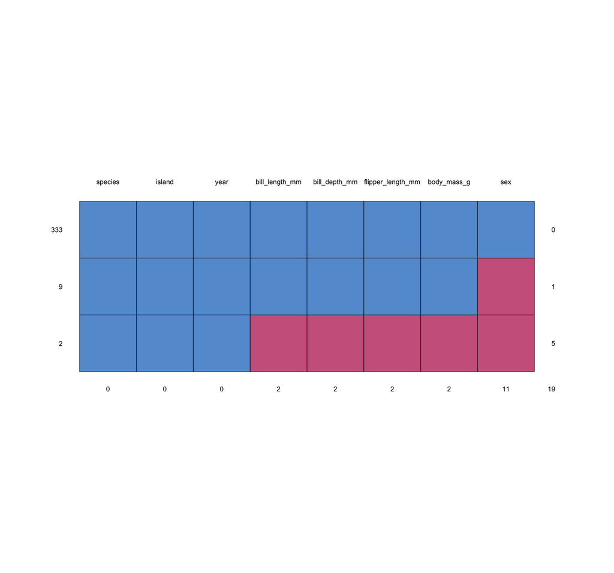

```
##     species island year bill_length_mm bill_depth_mm flipper_length_mm
## 333       1      1    1              1             1                 1
## 9         1      1    1              1             1                 1
## 2         1      1    1              0             0                 0
##           0      0    0              2             2                 2
##     body_mass_g sex
## 333           1   1  0
## 9             1   0  1
## 2             0   0  5
##               2  11 19
```

```r
mice::md.pattern(data)
```

z 344 zaznamov je 333 uplnych, pri 2 riadkoch chyba az 5 hodnot a pri 9 riadkoch chyba iba pohlavie.

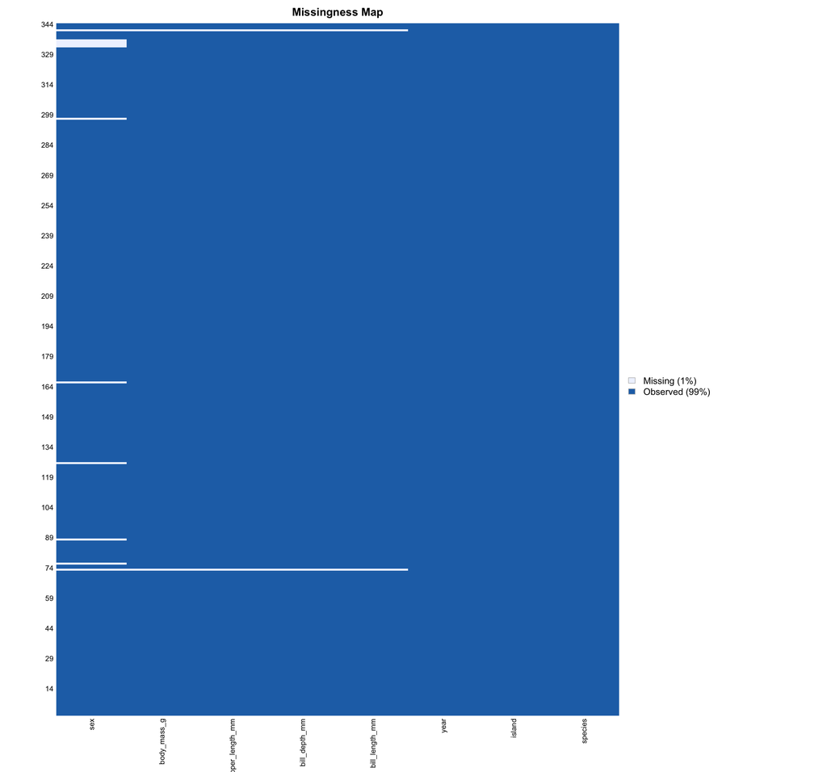

```r
Amelia::missmap(data)
```

vyradenych je 11 riadkov s chybajucimi hodnotami

```r
clean_data <- na.omit(data)

clean_data$bill_len <- clean_data$bill_length_mm
clean_data$bill_dep <- clean_data$bill_depth_mm
clean_data$flipper_len <- clean_data$flipper_length_mm
clean_data$body_mass <- clean_data$body_mass_g
```

# dlzka zobaka

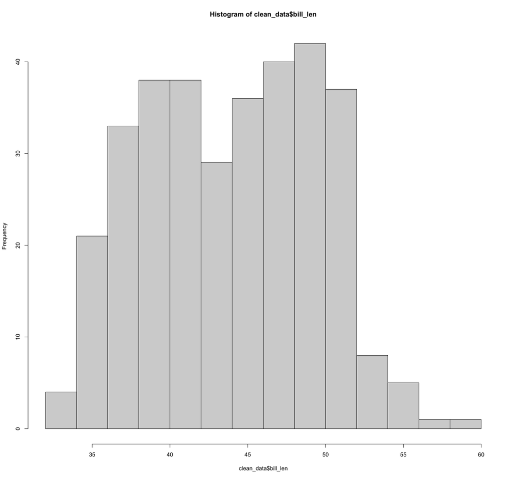

```r
hist(clean_data$bill_len)
```

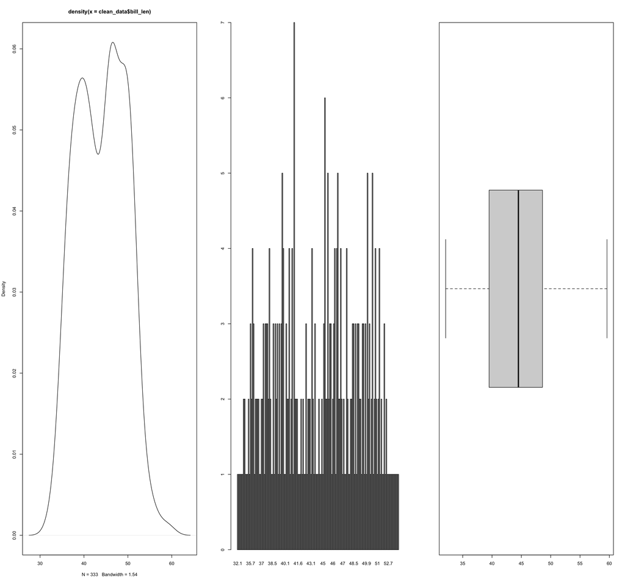

```r
par(mfrow = c(1, 3))
plot(density(clean_data$bill_len))
barplot(table(clean_data$bill_len))
boxplot(clean_data$bill_len, horizontal = T)
```

```r
mean(clean_data$bill_len)
```

```
## [1] 43.99279
```

```r
median(clean_data$bill_len)
```

```
## [1] 44.5
```

```r
modeest::mfv(clean_data$bill_len)
```

```
## [1] 41.1
```

```r
quantile(clean_data$bill_len)
```

```
##   0%  25%  50%  75% 100%
## 32.1 39.5 44.5 48.6 59.6
```

```r
range(clean_data$bill_len)
```

```
## [1] 32.1 59.6
```

```r
IQR(clean_data$bill_len)
```

```
## [1] 9.1
```

```r
var(clean_data$bill_len)
```

```
## [1] 29.90633
```

```r
sd(clean_data$bill_len)
```

```
## [1] 5.468668
```

typicka dlzka zobaka je problizne 44mm, median je 44.5mm co znamena ze polovica tucniakov ma zobak kratsi ako median polovica merani (1. a 3. kvantil - medzi 25% a 75% meranymi dat) lezi medzi 39.5mm a 48.6mm, sirka medzi kvartiloveho rozdielu je 9.1mm najkratsi zobak meral 32.1mm a najdlhsi 59.6mm, smerodajna odchylka je 5.47mm graf hustoty ma dva vrcholy, kedze su v datach tri druhy, tento tvar moze vznikat ich zmiesanim

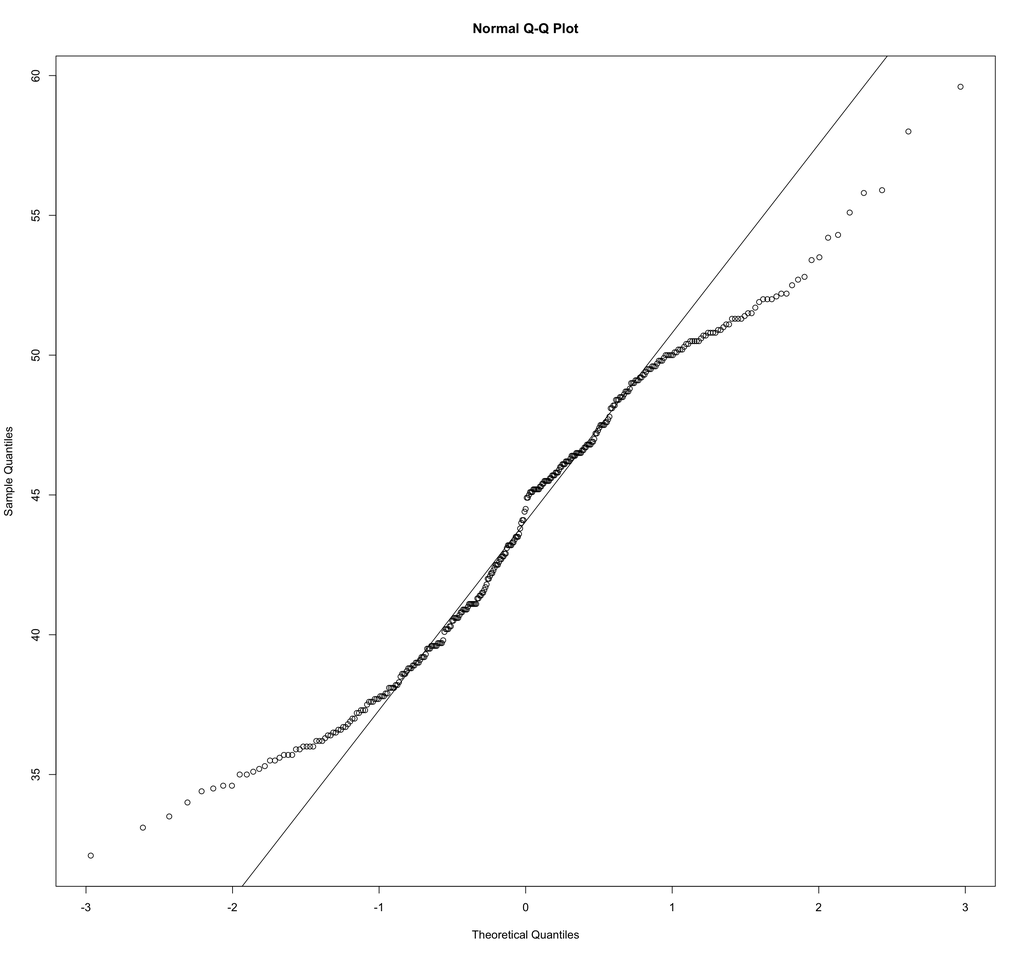

```r
qqnorm(clean_data$bill_len)
qqline(clean_data$bill_len)
```

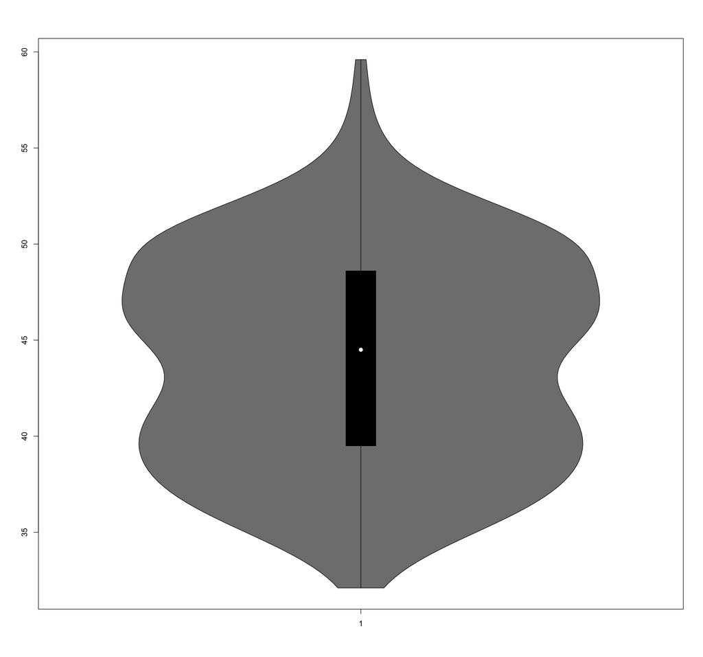

```r
vioplot::vioplot(clean_data$bill_len)
```

```r
moments::skewness(clean_data$bill_len)
```

```
## [1] 0.04513598
```

```r
moments::kurtosis(clean_data$bill_len)
```

```
## [1] 2.111827
```

suhrnne rozdelenie je priblizne symetricke, comu zodpoveda sikmost 0.045 merane su roky 2007 az 2009

## dlzka zobaka podla podskupin

### podla druhu

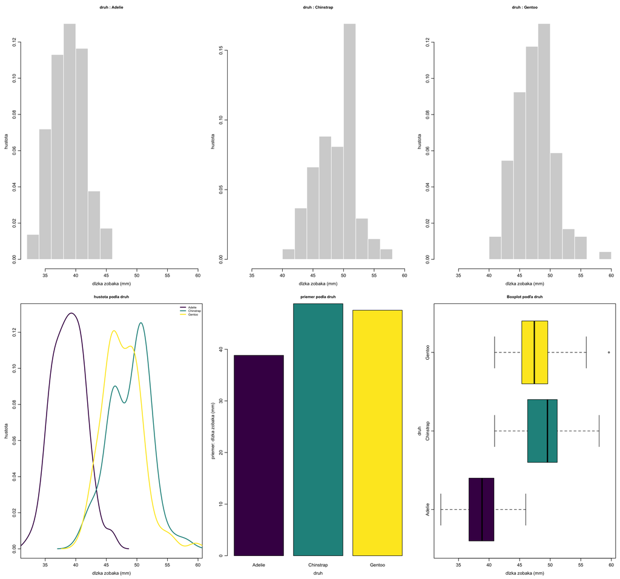

```r
grafy_podla_skupin(clean_data, stlpec = "bill_len", podla = "species", nazov_hodnoty = "dlzka zobaka (mm)", nazov_skupiny = "druh")
```

```r
popisne_statistiky(clean_data, stlpec = "bill_len", podla = "species")
```

```
## $Adelie
## $Adelie$count
## [1] 146
##
## $Adelie$mean
## [1] 38.82397
##
## $Adelie$median
## [1] 38.85
##
## $Adelie$modus
## [1] 41.1
##
## $Adelie$kvantily
##     0%    25%    50%    75%   100%
## 32.100 36.725 38.850 40.775 46.000
##
## $Adelie$rozsah
## minimum maximum
##    32.1    46.0
##
## $Adelie$IQR
## [1] 4.05
##
## $Adelie$rozptyl
## [1] 7.089421
##
## $Adelie$smerodajna_odchylka
## [1] 2.662597
##
##
## $Chinstrap
## $Chinstrap$count
## [1] 68
##
## $Chinstrap$mean
## [1] 48.83382
##
## $Chinstrap$median
## [1] 49.55
```

[output cut: 36 more lines]

```
##    0%   25%   50%   75%  100%
## 40.90 45.35 47.40 49.60 59.60
##
## $Gentoo$rozsah
## minimum maximum
##    40.9    59.6
##
## $Gentoo$IQR
## [1] 4.25
##
## $Gentoo$rozptyl
## [1] 9.647955
##
## $Gentoo$smerodajna_odchylka
## [1] 3.106116
```

Adelie maju vyrazne kratsie zobaky, ich priemer je o 10mm kratsi ako Chinstrap najvacsi prekryv maju Chinstrap a Gentoo, Chinstrap ma vacsi priemer o 1.27mm a median o 2.15mm najvacsiu smerodajnu odchylku 3.34mm ma Chinstrap a najmensiu 2.66mm Adelie pri Gentoo boxplot ukazuje vychylny bod 59.6mm

### podla ostrovu

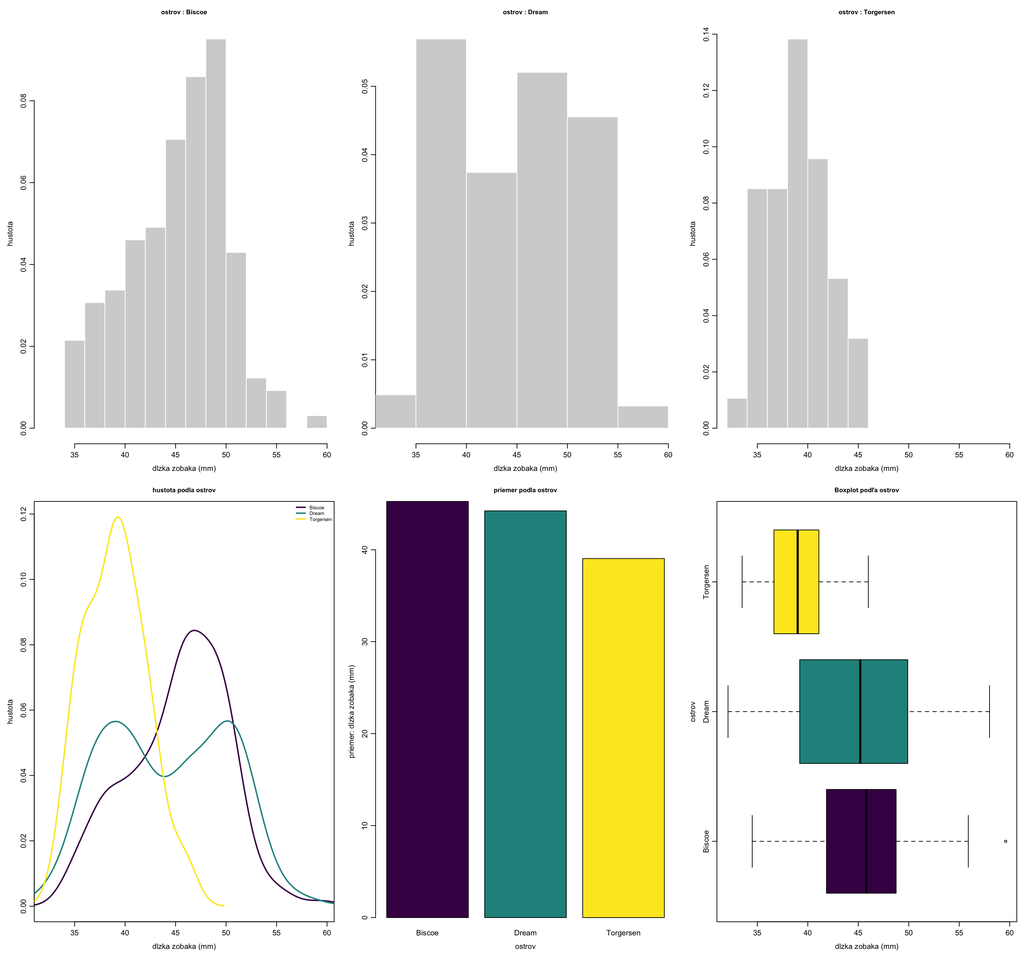

```r
grafy_podla_skupin(clean_data, stlpec = "bill_len", podla = "island", nazov_hodnoty = "dlzka zobaka (mm)", nazov_skupiny = "ostrov")
```

```r
popisne_statistiky(clean_data, stlpec = "bill_len", podla = "island")
```

```
## $Biscoe
## $Biscoe$count
## [1] 163
##
## $Biscoe$mean
## [1] 45.24847
##
## $Biscoe$median
## [1] 45.8
##
## $Biscoe$modus
## [1] 45.2 45.5 46.5 50.0
##
## $Biscoe$kvantily
##    0%   25%   50%   75%  100%
## 34.50 41.85 45.80 48.75 59.60
##
## $Biscoe$rozsah
## minimum maximum
##    34.5    59.6
##
## $Biscoe$IQR
## [1] 6.9
##
## $Biscoe$rozptyl
## [1] 23.30301
##
## $Biscoe$smerodajna_odchylka
## [1] 4.827319
##
##
## $Dream
## $Dream$count
## [1] 123
##
## $Dream$mean
## [1] 44.22195
##
## $Dream$median
## [1] 45.2
```

[output cut: 36 more lines]

```
##    0%   25%   50%   75%  100%
## 33.50 36.65 39.00 41.10 46.00
##
## $Torgersen$rozsah
## minimum maximum
##    33.5    46.0
##
## $Torgersen$IQR
## [1] 4.45
##
## $Torgersen$rozptyl
## [1] 9.169371
##
## $Torgersen$smerodajna_odchylka
## [1] 3.028097
```

najdlhsie zobaky podla priemeru maju tucniaky na ostrove Biscoe zlaty stred (median) je v rozmedzi 45.2mm a 45.8mm pre tucniaky z ostrovov Biscoe a Dream smerodajna odchylka je najmensia pri tucniakoch z ostrovu Torgersen 3.02mm, maju taktiez najnizsie maximum 46mm

### podla pohlavia

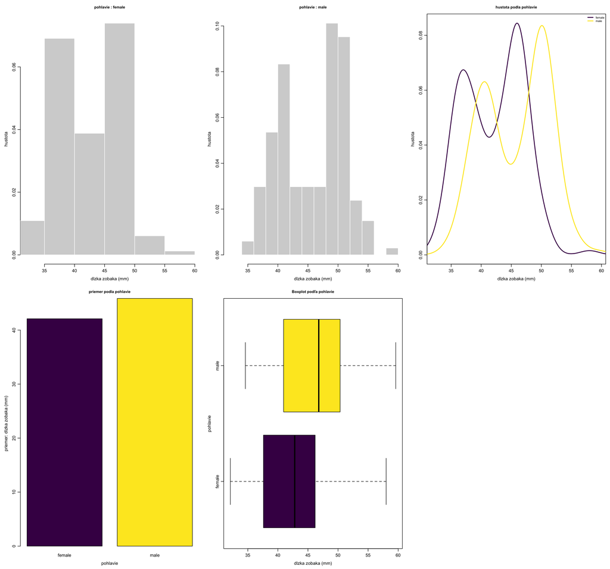

```r
grafy_podla_skupin(clean_data, stlpec = "bill_len", podla = "sex", nazov_hodnoty = "dlzka zobaka (mm)", nazov_skupiny = "pohlavie")
```

```r
popisne_statistiky(clean_data, stlpec = "bill_len", podla = "sex")
```

```
## $female
## $female$count
## [1] 165
##
## $female$mean
## [1] 42.09697
##
## $female$median
## [1] 42.8
##
## $female$modus
## [1] 46.5
##
## $female$kvantily
##   0%  25%  50%  75% 100%
## 32.1 37.6 42.8 46.2 58.0
##
## $female$rozsah
## minimum maximum
##    32.1    58.0
##
## $female$IQR
## [1] 8.6
##
## $female$rozptyl
## [1] 24.04408
##
## $female$smerodajna_odchylka
## [1] 4.903476
##
##
## $male
## $male$count
## [1] 168
##
## $male$mean
## [1] 45.85476
##
## $male$median
## [1] 46.8
##
## $male$modus
## [1] 41.1
##
## $male$kvantily
##     0%    25%    50%    75%   100%
## 34.600 40.975 46.800 50.325 59.600
##
## $male$rozsah
## minimum maximum
##    34.6    59.6
##
## $male$IQR
## [1] 9.35
##
## $male$rozptyl
## [1] 28.80357
##
## $male$smerodajna_odchylka
## [1] 5.366896
```

samci maju vacsi rozptyl dlzky zobaka 28.8 oproti 24.0 mm u samic maximum dlzky zobaka je u samcov 59.6 mm a u samic 58.0 mm najcastejsie vyskytujuca sa hodnota u samiciek je 46.5mm a u samcov 41.1mm (moze to byt aj z dovodu viacej merani u jedneho druhu alebo ostrova) median samcov je 46.8mm a samiciek 42.8mm, kde aj priemer blizko zasahuje: samci 45.9mm a samicky 42.1mm samci maju priemerne dlhsie zobaky, kde maju aj vacsi rozptyl

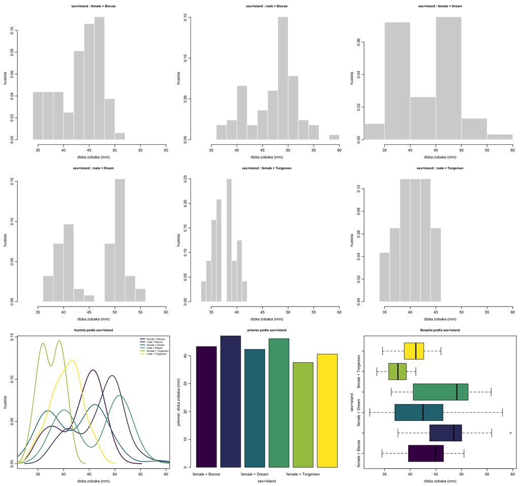

```r
grafy_podla_skupin(clean_data, stlpec = "bill_len", podla = "sex+island", nazov_hodnoty = "dlzka zobaka (mm)")
```

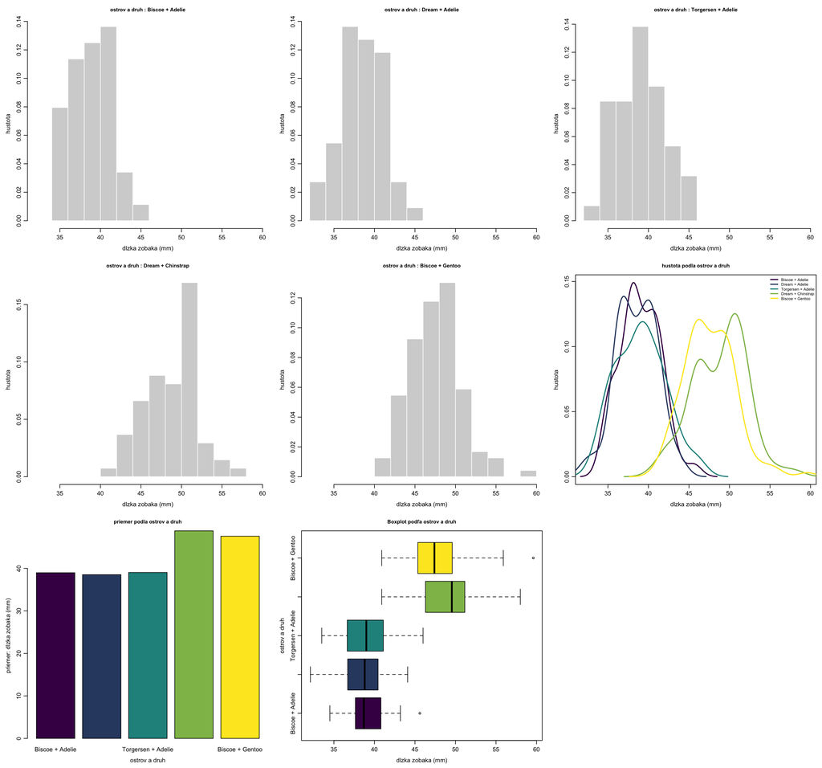

```r
grafy_podla_skupin(clean_data, stlpec = "bill_len", podla = "island+species", nazov_hodnoty = "dlzka zobaka (mm)", nazov_skupiny = "ostrov a druh")
```

rozdelenia dlzky zobaka sa medzi ostrovmi prekryvaju, treba brat do uvahy aj zastupenie druhov: na ostrove torgersen je iba adelie, zatial co na ostrove biscoe prevlada gentoo

```r
adelie <- subset(clean_data, species == "Adelie")
table(
  ostrov = factor(adelie$island, levels = c("Dream", "Biscoe", "Torgersen")),
  pohlavie = adelie$sex
)
```

```
##            pohlavie
## ostrov      female male
##   Dream         27   28
##   Biscoe        22   22
##   Torgersen     24   23
```

vzorky su rovnomerne rozlozene medzi pohlaviami

# hlbka zobaka

```r
popisne_statistiky(clean_data, stlpec = "bill_dep")
```

```
## $count
## [1] 333
##
## $mean
## [1] 17.16486
##
## $median
## [1] 17.3
##
## $modus
## [1] 17
##
## $kvantily
##   0%  25%  50%  75% 100%
## 13.1 15.6 17.3 18.7 21.5
##
## $rozsah
## minimum maximum
##    13.1    21.5
##
## $IQR
## [1] 3.1
##
## $rozptyl
## [1] 3.877888
##
## $smerodajna_odchylka
## [1] 1.969235
```

priemerna hlbka zobaka je 17.16mm, median 17.3mm a modus 17mm, smerodajna odchylka dat je 1.97mm

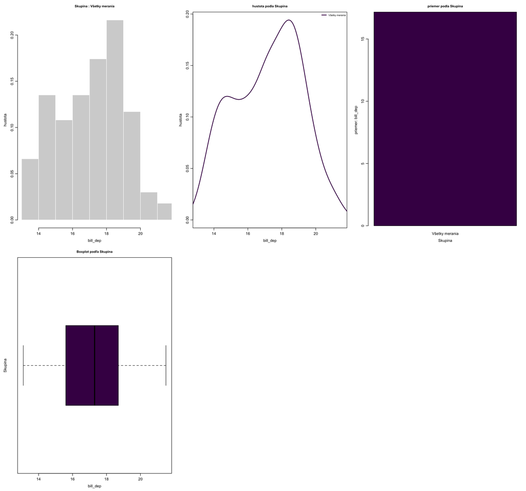

```r
grafy_podla_skupin(clean_data, stlpec = "bill_dep")
```

## podla podskupin

### podla pohlavia a ostrova

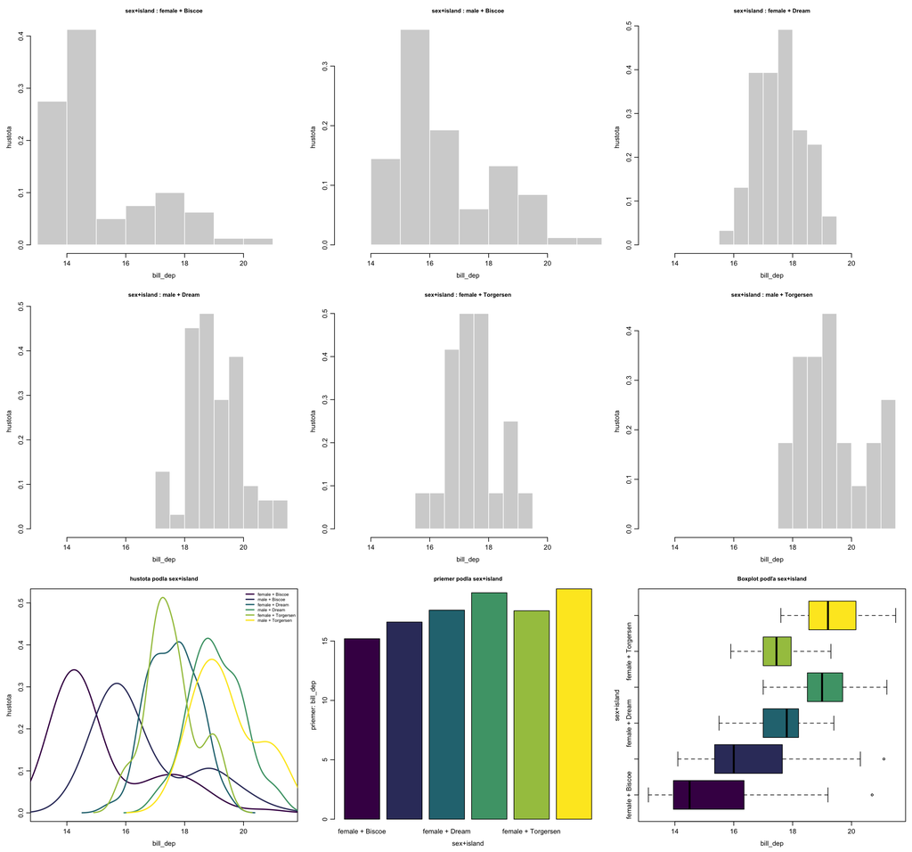

```r
grafy_podla_skupin(clean_data, stlpec = "bill_dep", podla = "sex+island")
```

```r
popisne_statistiky(clean_data, stlpec = "bill_dep", podla = "sex")
```

```
## $female
## $female$count
## [1] 165
##
## $female$mean
## [1] 16.42545
##
## $female$median
## [1] 17
##
## $female$modus
## [1] 17.8 17.9
##
## $female$kvantily
##   0%  25%  50%  75% 100%
## 13.1 14.5 17.0 17.8 20.7
##
## $female$rozsah
## minimum maximum
##    13.1    20.7
##
## $female$IQR
## [1] 3.3
##
## $female$rozptyl
## [1] 3.22447
##
## $female$smerodajna_odchylka
## [1] 1.795681
##
##
## $male
## $male$count
## [1] 168
##
## $male$mean
## [1] 17.89107
##
## $male$median
## [1] 18.45
##
## $male$modus
## [1] 18.5 19.0
##
## $male$kvantily
##     0%    25%    50%    75%   100%
## 14.100 16.075 18.450 19.250 21.500
##
## $male$rozsah
## minimum maximum
##    14.1    21.5
##
## $male$IQR
## [1] 3.175
##
## $male$rozptyl
## [1] 3.472075
##
## $male$smerodajna_odchylka
## [1] 1.863351
```

```r
popisne_statistiky(clean_data, stlpec = "bill_dep", podla = "island")
```

```
## $Biscoe
## $Biscoe$count
## [1] 163
##
## $Biscoe$mean
## [1] 15.90736
##
## $Biscoe$median
## [1] 15.6
##
## $Biscoe$modus
## [1] 15
##
## $Biscoe$kvantily
##   0%  25%  50%  75% 100%
## 13.1 14.5 15.6 17.0 21.1
##
## $Biscoe$rozsah
## minimum maximum
##    13.1    21.1
##
## $Biscoe$IQR
## [1] 2.5
##
## $Biscoe$rozptyl
## [1] 3.340316
##
## $Biscoe$smerodajna_odchylka
## [1] 1.827653
##
##
## $Dream
## $Dream$count
## [1] 123
##
## $Dream$mean
## [1] 18.33984
##
## $Dream$median
## [1] 18.4
```

[output cut: 36 more lines]

```
##    0%   25%   50%   75%  100%
## 15.90 17.45 18.40 19.25 21.50
##
## $Torgersen$rozsah
## minimum maximum
##    15.9    21.5
##
## $Torgersen$IQR
## [1] 1.8
##
## $Torgersen$rozptyl
## [1] 1.812988
##
## $Torgersen$smerodajna_odchylka
## [1] 1.346472
```

najmensi rozptyl hlbky zobaka je na ostrove Dream 1.29, na Torgersene je 1.81 a na Biscoe 3.34, za obe pohlavia spolu medzi tucniakov, ktore maju najhlbsie zobaky su samci z ostrovov Dream a Torgersen

### podla druhu

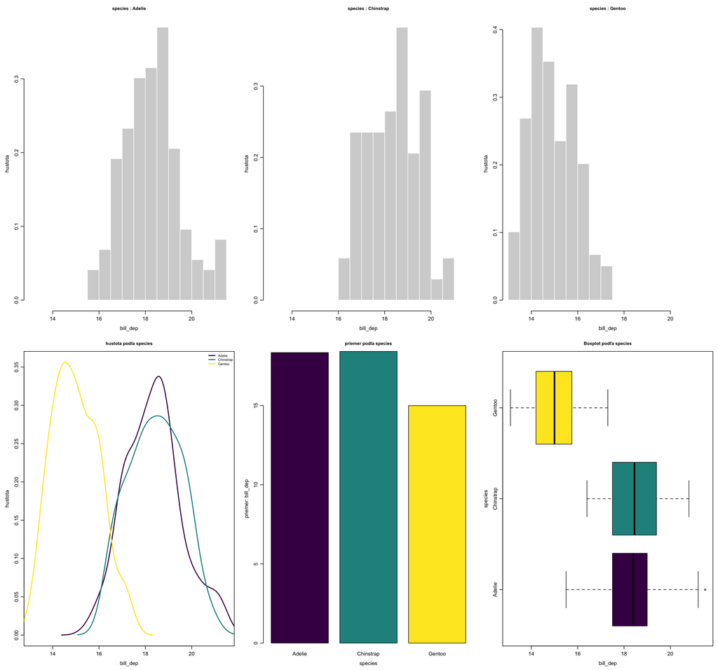

```r
grafy_podla_skupin(clean_data, stlpec = "bill_dep", podla = "species")
```

```r
popisne_statistiky(clean_data, stlpec = "bill_dep", podla = "species")
```

```
## $Adelie
## $Adelie$count
## [1] 146
##
## $Adelie$mean
## [1] 18.34726
##
## $Adelie$median
## [1] 18.4
##
## $Adelie$modus
## [1] 18.5
##
## $Adelie$kvantily
##   0%  25%  50%  75% 100%
## 15.5 17.5 18.4 19.0 21.5
##
## $Adelie$rozsah
## minimum maximum
##    15.5    21.5
##
## $Adelie$IQR
## [1] 1.5
##
## $Adelie$rozptyl
## [1] 1.486786
##
## $Adelie$smerodajna_odchylka
## [1] 1.219338
##
##
## $Chinstrap
## $Chinstrap$count
## [1] 68
##
## $Chinstrap$mean
## [1] 18.42059
##
## $Chinstrap$median
## [1] 18.45
```

[output cut: 36 more lines]

```
##    0%   25%   50%   75%  100%
## 13.10 14.20 15.00 15.75 17.30
##
## $Gentoo$rozsah
## minimum maximum
##    13.1    17.3
##
## $Gentoo$IQR
## [1] 1.55
##
## $Gentoo$rozptyl
## [1] 0.972192
##
## $Gentoo$smerodajna_odchylka
## [1] 0.985998
```

najhlbsie zobaky maju druhy Adelie a Chinstrap, Adelie ma vacsi rozptyl 1.49 a Chinstrap najvacsi IQR 1.9mm. Adelie a Chinstrap maju takmer zhodny priemer okolo 18.4mm druh Gentoo patri k druhom s mensiou hlbkou, kde priemerna hodnota je 15mm a median 15mm s rovnakym modusom

## korelacia hlbky zobaka a dlzky podla pohlavia

obe pohlavia naraz pre scatter plot korelacie

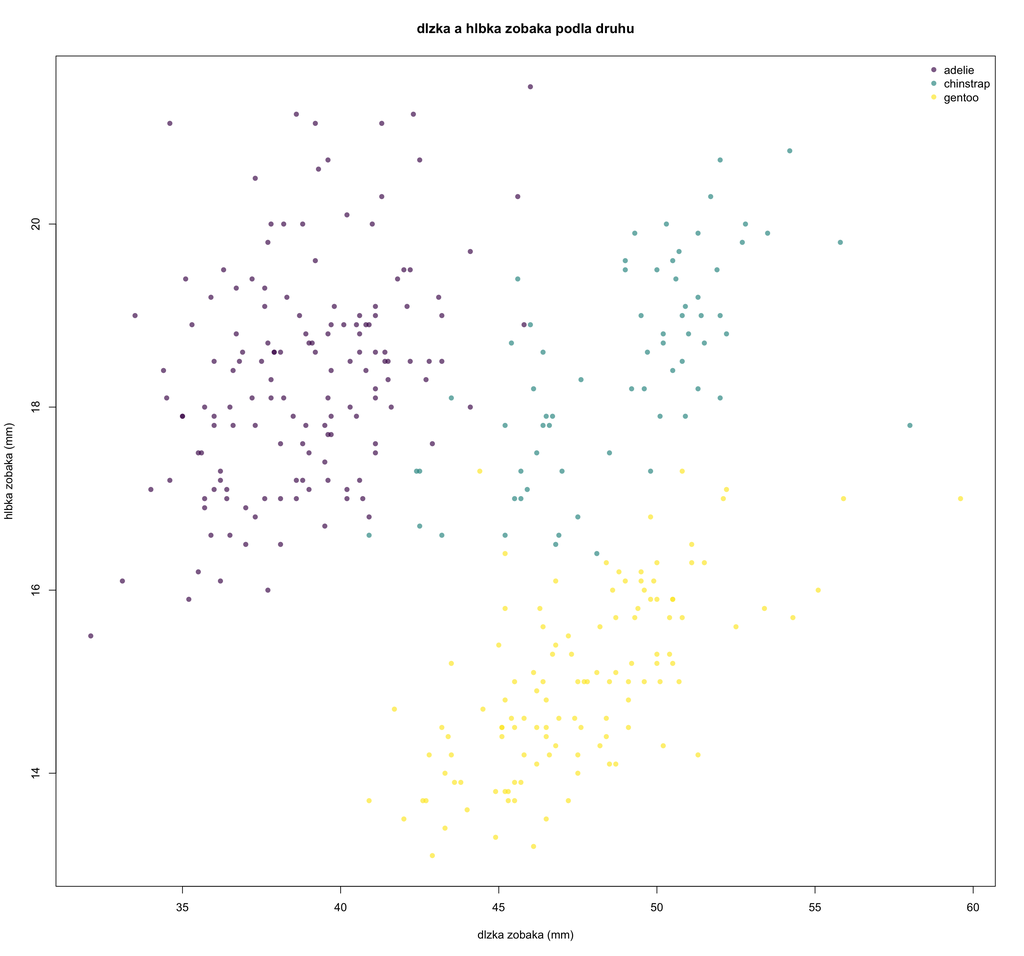

```r
farby_druhov <- viridisLite::viridis(nlevels(clean_data$species), alpha = 0.65)
plot(clean_data$bill_len, clean_data$bill_dep,
     col = farby_druhov[clean_data$species], pch = 16,
     xlab = "dlzka zobaka (mm)", ylab = "hlbka zobaka (mm)", main = "dlzka a hlbka zobaka podla druhu")

legend("topright", legend = tolower(levels(clean_data$species)),
       col = farby_druhov, pch = 16, bty = "n")
```

```r
podla_pohlavia <- split(clean_data, clean_data$sex)
cor(podla_pohlavia$female$bill_len, podla_pohlavia$female$bill_dep)
```

```
## [1] -0.4263804
```

```r
cor(podla_pohlavia$male$bill_len, podla_pohlavia$male$bill_dep)
```

```
## [1] -0.3952939
```

pri spojeni druhov je korelacia zaporna, samice -0.43 a samci -0.40 rozdiely medzi druhmi mozu tento smer vztahu ovplyvnit.

```r
adelie_samice <- podla_pohlavia$female[podla_pohlavia$female$species == "Adelie",]
cor(adelie_samice$bill_len, adelie_samice$bill_dep)
```

```
## [1] 0.1606361
```

```r
adelie_samce <- podla_pohlavia$male[podla_pohlavia$male$species == "Adelie",]
cor(adelie_samce$bill_len, adelie_samce$bill_dep)
```

```
## [1] -0.03824716
```

u samcov druhu adelie je korelacia blizka nule -0.04, u samic je 0.16

```r
chinstrap_samice <- podla_pohlavia$female[podla_pohlavia$female$species == "Chinstrap",]
cor(chinstrap_samice$bill_len, chinstrap_samice$bill_dep)
```

```
## [1] 0.2563171
```

```r
chinstrap_samce <- podla_pohlavia$male[podla_pohlavia$male$species == "Chinstrap",]
cor(chinstrap_samce$bill_len, chinstrap_samce$bill_dep)
```

```
## [1] 0.4462703
```

pri samcoch je silnejsia korelacia 0.45 medzi dlzkou a hlbkou, cim dlhsi zobak tym hlbsi

```r
gentoo_samice <- podla_pohlavia$female[podla_pohlavia$female$species == "Gentoo",]
cor(gentoo_samice$bill_len, gentoo_samice$bill_dep)
```

```
## [1] 0.430444
```

```r
gentoo_samce <- podla_pohlavia$male[podla_pohlavia$male$species == "Gentoo",]
cor(gentoo_samce$bill_len, gentoo_samce$bill_dep)
```

```
## [1] 0.3067675
```

u samic druhu Gentoo je korelacia medzi dlzkou a hlbkou zobaka 0.43 a u samcov 0.31, v tejto skupine sa dlhsie zobaky spajaju s vacsou hlbkou

po rozdeleni podla druhu je korelacia vacsinou kladna, zatial co pri spojeni druhov je zaporna

# dlzka plutvy

```r
popisne_statistiky(clean_data, stlpec = "flipper_len")
```

```
## $count
## [1] 333
##
## $mean
## [1] 200.967
##
## $median
## [1] 197
##
## $modus
## [1] 190
##
## $kvantily
##   0%  25%  50%  75% 100%
##  172  190  197  213  231
##
## $rozsah
## minimum maximum
##     172     231
##
## $IQR
## [1] 23
##
## $rozptyl
## [1] 196.4417
##
## $smerodajna_odchylka
## [1] 14.01577
```

priemerna dlzka plutvy je 200.97mm, median 197mm a modus 190mm, smerodajna odchylka dat je 14.01 IQR je 23, kde minimum je 172mm a maximum 231mm

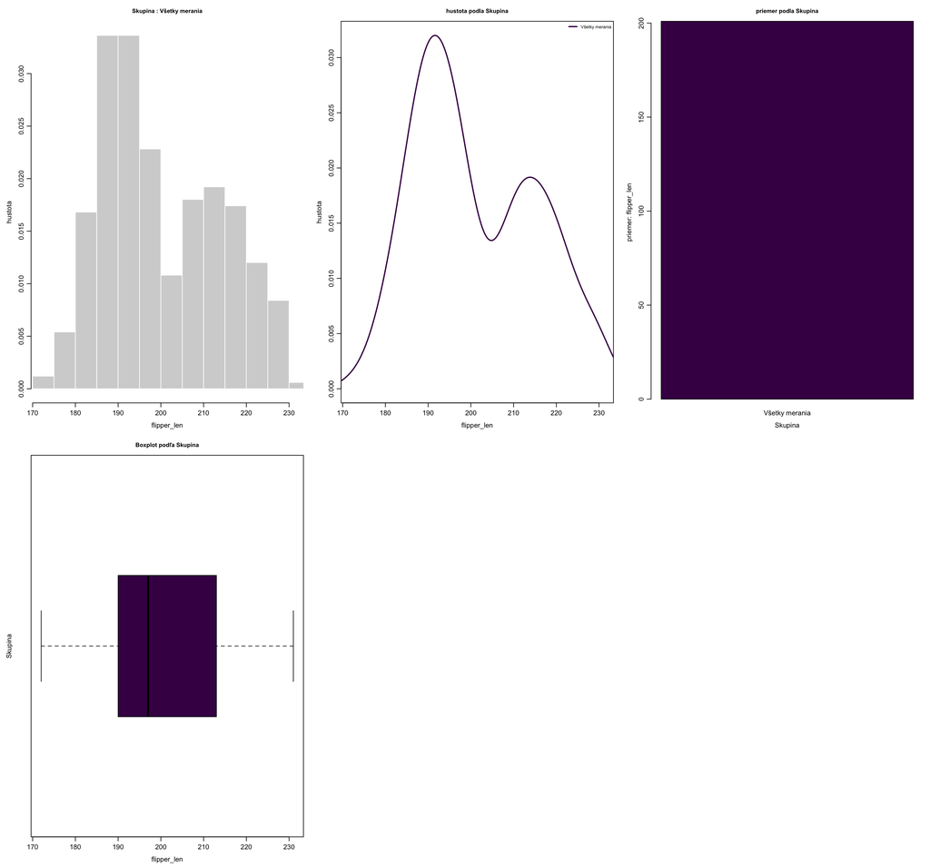

```r
grafy_podla_skupin(clean_data, stlpec = "flipper_len")
```

## podla podskupin

### podla pohlavia a ostrova

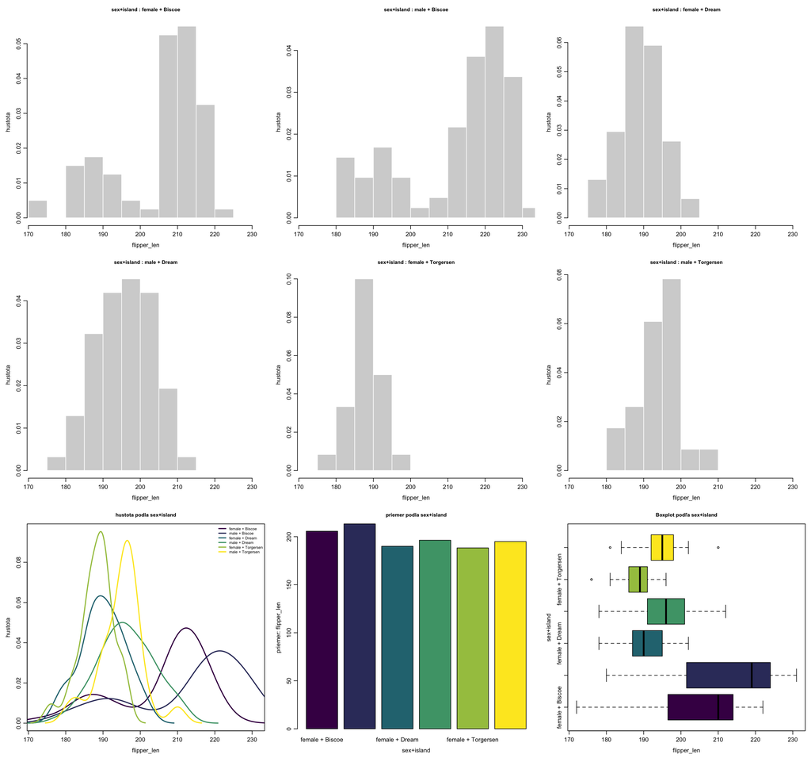

```r
grafy_podla_skupin(clean_data, stlpec = "flipper_len", podla = "sex+island")
```

```r
popisne_statistiky(clean_data, stlpec = "flipper_len", podla = "sex")
```

```
## $female
## $female$count
## [1] 165
##
## $female$mean
## [1] 197.3636
##
## $female$median
## [1] 193
##
## $female$modus
## [1] 187
##
## $female$kvantily
##   0%  25%  50%  75% 100%
##  172  187  193  210  222
##
## $female$rozsah
## minimum maximum
##     172     222
##
## $female$IQR
## [1] 23
##
## $female$rozptyl
## [1] 156.2694
##
## $female$smerodajna_odchylka
## [1] 12.50078
##
##
## $male
## $male$count
## [1] 168
##
## $male$mean
## [1] 204.506
##
## $male$median
## [1] 200.5
##
## $male$modus
## [1] 190 197
##
## $male$kvantily
##    0%   25%   50%   75%  100%
## 178.0 193.0 200.5 219.0 231.0
##
## $male$rozsah
## minimum maximum
##     178     231
##
## $male$IQR
## [1] 26
##
## $male$rozptyl
## [1] 211.6407
##
## $male$smerodajna_odchylka
## [1] 14.54788
```

```r
popisne_statistiky(clean_data, stlpec = "flipper_len", podla = "island")
```

```
## $Biscoe
## $Biscoe$count
## [1] 163
##
## $Biscoe$mean
## [1] 209.5583
##
## $Biscoe$median
## [1] 213
##
## $Biscoe$modus
## [1] 215
##
## $Biscoe$kvantily
##    0%   25%   50%   75%  100%
## 172.0 198.5 213.0 220.0 231.0
##
## $Biscoe$rozsah
## minimum maximum
##     172     231
##
## $Biscoe$IQR
## [1] 21.5
##
## $Biscoe$rozptyl
## [1] 203.9889
##
## $Biscoe$smerodajna_odchylka
## [1] 14.28247
##
##
## $Dream
## $Dream$count
## [1] 123
##
## $Dream$mean
## [1] 193.187
##
## $Dream$median
## [1] 193
```

[output cut: 36 more lines]

```
##    0%   25%   50%   75%  100%
## 176.0 187.5 191.0 195.5 210.0
##
## $Torgersen$rozsah
## minimum maximum
##     176     210
##
## $Torgersen$IQR
## [1] 8
##
## $Torgersen$rozptyl
## [1] 38.68918
##
## $Torgersen$smerodajna_odchylka
## [1] 6.220062
```

najmensi rozptyl maju tucniaky na ostrove Torgersen, kde su aj 3 vychylky

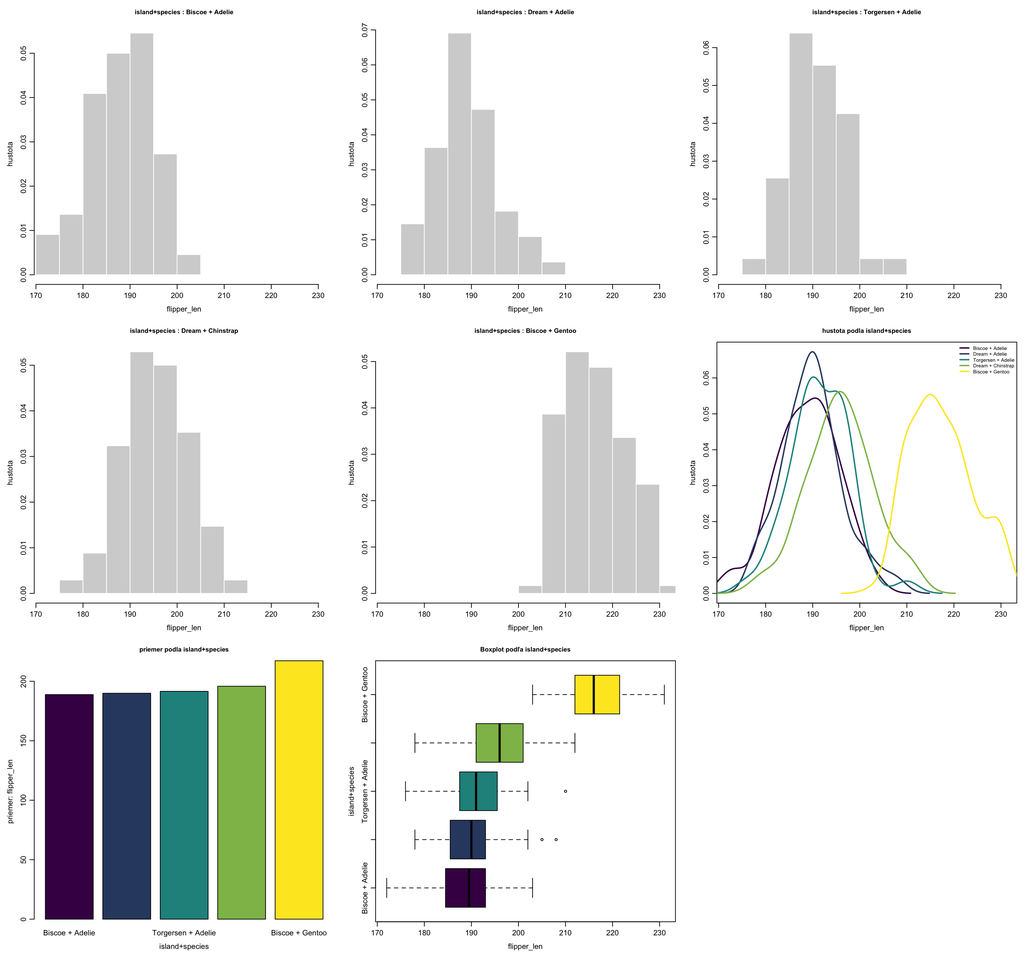

```r
grafy_podla_skupin(clean_data, stlpec = "flipper_len", podla = "island+species")
```

```r
popisne_statistiky(clean_data, stlpec = "flipper_len", podla = "island+species")
```

```
## $`Biscoe + Adelie`
## $`Biscoe + Adelie`$count
## [1] 44
##
## $`Biscoe + Adelie`$mean
## [1] 188.7955
##
## $`Biscoe + Adelie`$median
## [1] 189.5
##
## $`Biscoe + Adelie`$modus
## [1] 180 185 187 190 191 192 193
##
## $`Biscoe + Adelie`$kvantily
##     0%    25%    50%    75%   100%
## 172.00 184.75 189.50 193.00 203.00
##
## $`Biscoe + Adelie`$rozsah
## minimum maximum
##     172     203
##
## $`Biscoe + Adelie`$IQR
## [1] 8.25
##
## $`Biscoe + Adelie`$rozptyl
## [1] 45.28277
##
## $`Biscoe + Adelie`$smerodajna_odchylka
## [1] 6.729247
##
##
## $`Dream + Adelie`
## $`Dream + Adelie`$count
## [1] 55
##
## $`Dream + Adelie`$mean
## [1] 189.9273
##
## $`Dream + Adelie`$median
## [1] 190
```

[output cut: 98 more lines]

```
##    0%   25%   50%   75%  100%
## 203.0 212.0 216.0 221.5 231.0
##
## $`Biscoe + Gentoo`$rozsah
## minimum maximum
##     203     231
##
## $`Biscoe + Gentoo`$IQR
## [1] 9.5
##
## $`Biscoe + Gentoo`$rozptyl
## [1] 43.3679
##
## $`Biscoe + Gentoo`$smerodajna_odchylka
## [1] 6.585431
```

najdlhsie plutvy a najvacsi rozptyl ich dlzky su na ostrove Biscoe na tomto ostrove vsak prevlada druh Gentoo, ktory ma celkovo dlhsie plutvy

### podla druhu

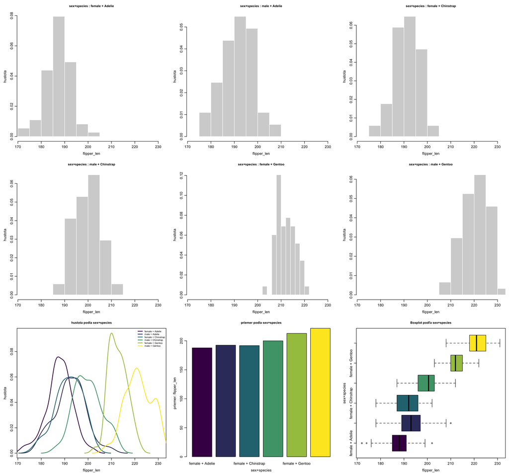

```r
grafy_podla_skupin(clean_data, stlpec = "flipper_len", podla = "sex+species")
```

```r
popisne_statistiky(clean_data, stlpec = "flipper_len", podla = "species")
```

```
## $Adelie
## $Adelie$count
## [1] 146
##
## $Adelie$mean
## [1] 190.1027
##
## $Adelie$median
## [1] 190
##
## $Adelie$modus
## [1] 190
##
## $Adelie$kvantily
##   0%  25%  50%  75% 100%
##  172  186  190  195  210
##
## $Adelie$rozsah
## minimum maximum
##     172     210
##
## $Adelie$IQR
## [1] 9
##
## $Adelie$rozptyl
## [1] 42.5342
##
## $Adelie$smerodajna_odchylka
## [1] 6.521825
##
##
## $Chinstrap
## $Chinstrap$count
## [1] 68
##
## $Chinstrap$mean
## [1] 195.8235
##
## $Chinstrap$median
## [1] 196
```

[output cut: 36 more lines]

```
##    0%   25%   50%   75%  100%
## 203.0 212.0 216.0 221.5 231.0
##
## $Gentoo$rozsah
## minimum maximum
##     203     231
##
## $Gentoo$IQR
## [1] 9.5
##
## $Gentoo$rozptyl
## [1] 43.3679
##
## $Gentoo$smerodajna_odchylka
## [1] 6.585431
```

najdlhsie plutvy maju tucniaky druhu Gentoo, kde je aj najvacsia priemerna hodnota 217.24mm s medianom 216 (obe pohlavia) pri druhu Gentoo je smerodajna odchylka 6.59mm a IQR 9.5, prvy kvartil je 212mm a treti 221.5mm

# vaha tela

```r
popisne_statistiky(clean_data, stlpec = "body_mass")
```

```
## $count
## [1] 333
##
## $mean
## [1] 4207.057
##
## $median
## [1] 4050
##
## $modus
## [1] 3800
##
## $kvantily
##   0%  25%  50%  75% 100%
## 2700 3550 4050 4775 6300
##
## $rozsah
## minimum maximum
##    2700    6300
##
## $IQR
## [1] 1225
##
## $rozptyl
## [1] 648372.5
##
## $smerodajna_odchylka
## [1] 805.2158
```

priemerna hmotnost tela je 4207g, median 4050g a modus 3800g, smerodajna odchylka dat je 805.22 IQR je 1225, kde minimum je 2700g a maximum 6300g

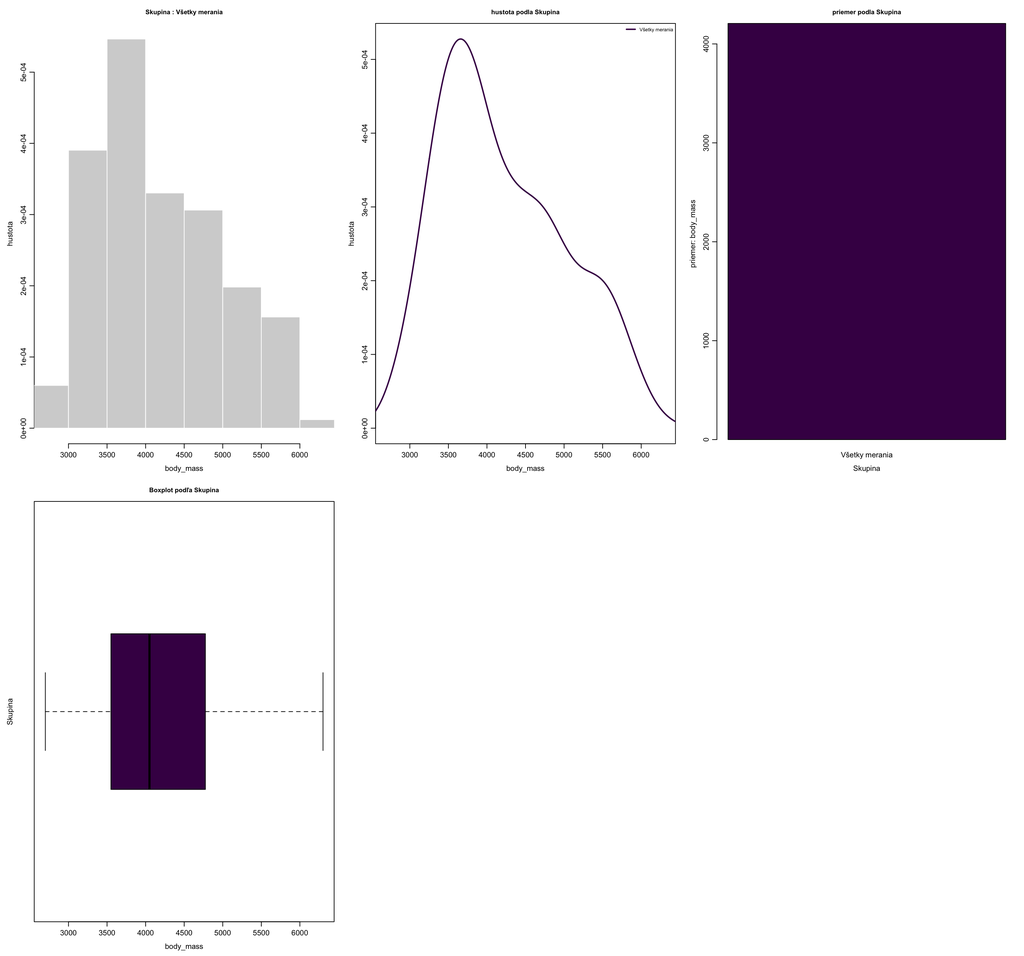

```r
grafy_podla_skupin(clean_data, stlpec = "body_mass")
```

## podla podskupin

### podla ostrova

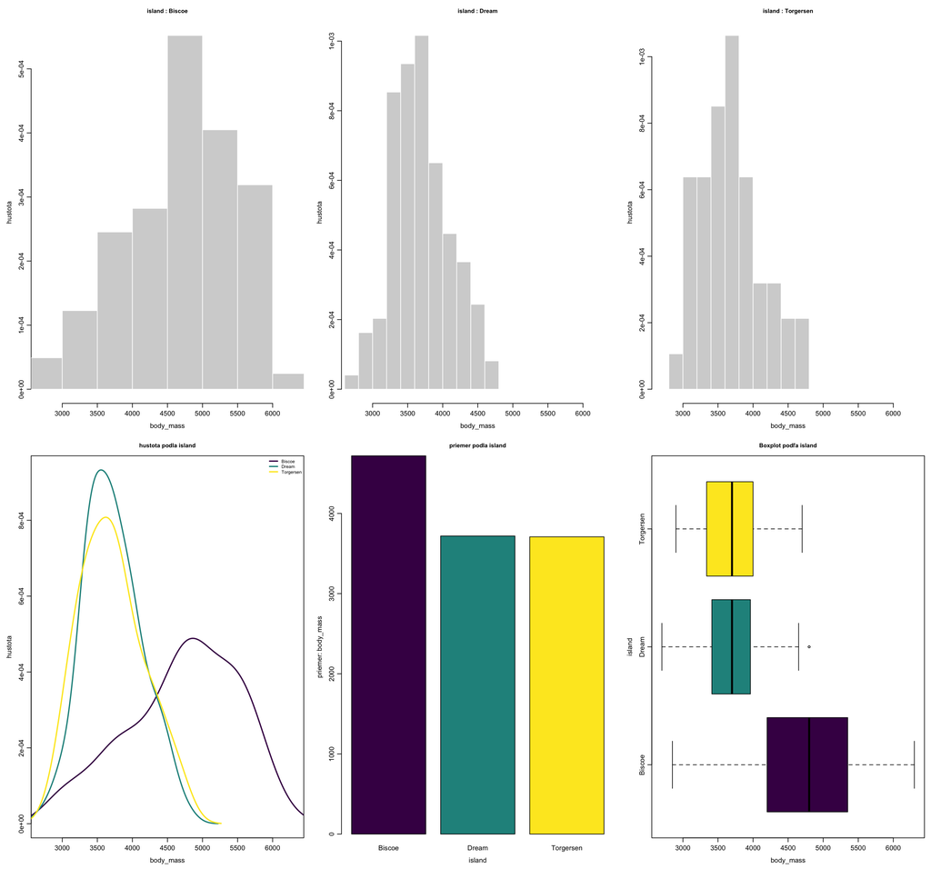

```r
grafy_podla_skupin(clean_data, stlpec = "body_mass", podla = "island")
```

```r
popisne_statistiky(clean_data, stlpec = "body_mass", podla = "island")
```

```
## $Biscoe
## $Biscoe$count
## [1] 163
##
## $Biscoe$mean
## [1] 4719.172
##
## $Biscoe$median
## [1] 4800
##
## $Biscoe$modus
## [1] 5000 5550
##
## $Biscoe$kvantily
##   0%  25%  50%  75% 100%
## 2850 4200 4800 5350 6300
##
## $Biscoe$rozsah
## minimum maximum
##    2850    6300
##
## $Biscoe$IQR
## [1] 1150
##
## $Biscoe$rozptyl
## [1] 625459.6
##
## $Biscoe$smerodajna_odchylka
## [1] 790.8601
##
##
## $Dream
## $Dream$count
## [1] 123
##
## $Dream$mean
## [1] 3718.902
##
## $Dream$median
## [1] 3700
```

[output cut: 36 more lines]

```
##     0%    25%    50%    75%   100%
## 2900.0 3337.5 3700.0 4000.0 4700.0
##
## $Torgersen$rozsah
## minimum maximum
##    2900    4700
##
## $Torgersen$IQR
## [1] 662.5
##
## $Torgersen$rozptyl
## [1] 204165.1
##
## $Torgersen$smerodajna_odchylka
## [1] 451.8464
```

najtazsie su tucniaky na ostrove Biscoe, kde je najvacsia smerodajna odchylka 790 s IQR 1150 na tomto ostrove je aj najvacsie maximum 6300g, kde priemerna hodnota je 4719g

### podla druhu a pohlavia

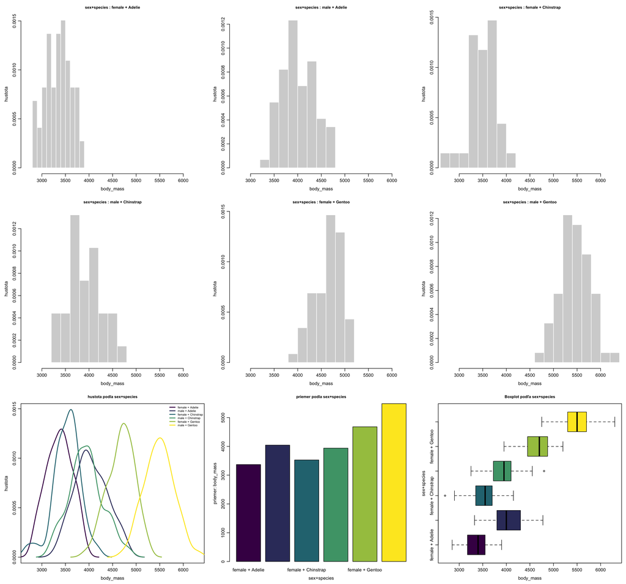

```r
grafy_podla_skupin(clean_data, stlpec = "body_mass", podla = "sex+species")
```

```r
popisne_statistiky(clean_data, stlpec = "body_mass", podla = "sex+species")
```

```
## $`female + Adelie`
## $`female + Adelie`$count
## [1] 73
##
## $`female + Adelie`$mean
## [1] 3368.836
##
## $`female + Adelie`$median
## [1] 3400
##
## $`female + Adelie`$modus
## [1] 3450
##
## $`female + Adelie`$kvantily
##   0%  25%  50%  75% 100%
## 2850 3175 3400 3550 3900
##
## $`female + Adelie`$rozsah
## minimum maximum
##    2850    3900
##
## $`female + Adelie`$IQR
## [1] 375
##
## $`female + Adelie`$rozptyl
## [1] 72565.64
##
## $`female + Adelie`$smerodajna_odchylka
## [1] 269.3801
##
##
## $`male + Adelie`
## $`male + Adelie`$count
## [1] 73
##
## $`male + Adelie`$mean
## [1] 4043.493
##
## $`male + Adelie`$median
## [1] 4000
```

[output cut: 129 more lines]

```
##   0%  25%  50%  75% 100%
## 4750 5300 5500 5700 6300
##
## $`male + Gentoo`$rozsah
## minimum maximum
##    4750    6300
##
## $`male + Gentoo`$IQR
## [1] 400
##
## $`male + Gentoo`$rozptyl
## [1] 98068.31
##
## $`male + Gentoo`$smerodajna_odchylka
## [1] 313.1586
```

v priemere (5484.8g a 4679.7g) su najtazsie tucniaky druhu Gentoo, kde maju najvyssi median pre samca 5500g a pre samicku 4700g najvacsie IQR maju samci Adelie 500, samicky Gentoo 412.5

## korelacia hmotnosti tela a dlzky plutvy

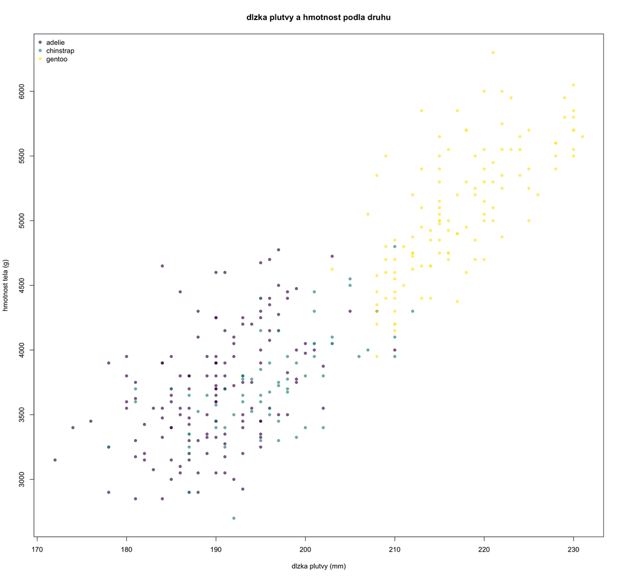

```r
plot(clean_data$flipper_len, clean_data$body_mass,
     col = farby_druhov[clean_data$species], pch = 16,
     xlab = "dlzka plutvy (mm)", ylab = "hmotnost tela (g)", main = "dlzka plutvy a hmotnost podla druhu")

legend("topleft", legend = tolower(levels(clean_data$species)),
       col = farby_druhov, pch = 16, bty = "n")
```

```r
cor(podla_pohlavia$female$body_mass, podla_pohlavia$female$flipper_len)
```

```
## [1] 0.884825
```

```r
cor(podla_pohlavia$male$body_mass, podla_pohlavia$male$flipper_len)
```

```
## [1] 0.8654987
```

pri spojenych druhoch je korelacia medzi dlzkou plutvy a hmotnostou silna, 0.88 u samic a 0.87 u samcov cast tohto vztahu mozu tvorit rozdiely medzi druhmi

```r
cor(adelie_samice$body_mass, adelie_samice$flipper_len)
```

```
## [1] 0.2629296
```

```r
cor(adelie_samce$body_mass, adelie_samce$flipper_len)
```

```
## [1] 0.3604345
```

```r
cor(chinstrap_samice$body_mass, chinstrap_samice$flipper_len)
```

```
## [1] 0.24215
```

```r
cor(chinstrap_samce$body_mass, chinstrap_samce$flipper_len)
```

```
## [1] 0.6645877
```

spomedzi sestich skupin podla druhu a pohlavia je najsilnejsia korelacia u samcov druhu Chinstrap 0.66

```r
cor(gentoo_samice$body_mass, gentoo_samice$flipper_len)
```

```
## [1] 0.487618
```

```r
cor(gentoo_samce$body_mass, gentoo_samce$flipper_len)
```

```
## [1] 0.330452
```

u druhu Gentoo je korelacia medzi hmotnostou a dlzkou plutvy silnejsia u samic 0.49 ako u samcov 0.33